# PEP: A metric for evaluating the importance of tackles

Robert Bajons, Jan-Ole Koslik, Rouven Michels, Marius Ötting

04/01/24

> “Football is two things. It’s blocking and tackling.”

> *Vince Lombardi*

## Introduction

Although this citation dates back several decades — and American Football has of course changed since then — tackling remains an integral aspect of the game. In contrast to decision-making scenarios faced by players, such as a quarterback’s selection of a target for a pass, the decision for a tackle is more straightforward: a defense player should always promptly tackle the ball carrier.

When assessing players’ tackles, one is usually interested in a hypothetical scenario: the potential outcome if a player were to miss a tackle. Essentially, this involves quantifying the yards saved by a defensive player. Ideally, albeit impractically, running a play twice — once with the defense player executing the tackle and a second time without — would allow a direct comparison of the yardage gained by the ball carrier, thus enabling to evaluate the impact of the defensive player’s tackle.

Given the impracticability of such a hypothetical scenario, our approach involves approximating it by predicting the yardline of the ongoing play twice. First, we consider the inclusion of the closest defender who executed the tackle, and in a next step, we exclude this player. However, only quantifying the yards safed by a particular tackle does not suffice as an adequate measure of tackle value, due to lack of interpretability on a scale truely relevant to the game outcome. Therefore, we aim to produce a measure of tackle value on the scale of expected points (EP). EP can be viewed as a complicated mapping of the end of play yardline to the expected points in the next play. A sole point prediction of the mean yard line misses uncertainty propagation to the EP scale, such that we aim to produce a full conditional density estimate to calculate the expected points from. The metric derived from this methodology then quantifies the *prevented expected points (PEP)*.

## Data

To accurately predict the yardline at the end of any given play it is necessary to create several features derived from the tracking data. More specifically, we conducted the following feature preprocessing:

#### Change of coordinate system

We transformed the coordinate system by

- redefining the x variable as the x distance to the endzone (such that all play directions are from right to left and the relevant endzone is at zero),
- centering the y-variable such that the center of the field is at zero,
- changing the direction variable, such that zero degrees represents heading straight towards the relevant endzone.

#### Response variable: Yards to be gained

For each play, we defined the x position of the ball carrier in the last frame as the end-of-play yard line. The response variable we aim to predict is now *yards to be gained* as the difference of the x position of the ballcarrier in a given frame to the end-of-play yard line.

#### Feature engineering

For all players and the ball carrier we use the features already contained in the tracking data, namely x- and y-coordinates, speed, acceleration, distance covered, orientation and direction.

For all players except the ball carrier we further compute

- euclidean distance to the ball carrier,
- x-distance to the ball carrier,
- y-distance to the ball carrier.

For defensive players only, we additionally compute the absolute difference of the defender’s direction and the angle of the shortest segement between the defender and the ball carrier.

Subsequently we order all players (in each frame) with respect to their euclidean distance to the ball carrier and standardize all features.

We did not rely on the event column to identify tackle events, but defined as the tackle event the frame in which the tacklers distance to the ballcarrier is minimal within a given play.

## Analysis

Our analysis comprises four steps:

#### 1. Model Training

We train a model designed to predict the yards to be gained which can be backtransformed into a prediction for the end-of-play yardline (see Yurko et al., 2020). The model uses the previously described features, only including the 10 closest defenders. While accounting for the time-series nature of the data by using e.g. a transformer architecture could be beneficial, we do not only want to obtain a point estimate for the yard line at the end of the play. Therefore, and to account for potential non-linear and interaction effects and to end up with a conditional density estimator $\hat{f}(y \mid x)$, we consider a random forest comprising 1000 individual trees, treating some accuracy in mean prediction for adequate uncertainty quantification. In general, modeling the uncertainty is important, as for example, in high-yardage plays, the variance of the end of play yardline is considerably larger, than in low-yardage plays.

#### 2. Tackler Replacement Procedure

For each tackle, we systematically remove the closest defender at the tackle moment, replacing his features with those of the second closest defender. We replace the second closest with the third closest, and so on. We do this, to produce a prediction for the hypothetical “what if” scenario, to compare to the existing tackle.

#### 3. Yardline Prediction

Using the trained random forest, we predict the end-of-play yardline across the 1000 trees. Using a kernel density estimator for visualization, we can plot the dynamically evolving conditional density estimation withing any given play.

For the tackle frames in particular, we obtain one predictive density, based on the original features, and one based on the replacement procedure explained above.

#### 4. Tackle Evaluation

Instead of a two-step procedure, first obtaining a kernel density estimate from the individual tree predictions (introducing subjectivity in bandwidth choice) and then integrating numerically, we treat the tree-predictions $\hat{y}_1, \dots, \hat{y}_{1000}$ as samples from the conditional density and approximate the above expectation via the Monte Carlo estimate
$$\frac{1}{1000} \sum_{i=1}^{1000} g(\hat{y}_i).$$

A metric for quantifying tackle value can now be obtained in two ways. Either, the hypothetical expected points can be compared to the mean expected points based on predicted conditional density using the original features, i.e.
$$\text{E}(g(y) \mid x_0) - \text{E}(g(y) \mid x_1),$$
where $x_0$ denotes the transformed features after removing the closest defender and $x_1$ denotes the original features. This metric can be considered the treatment effect of the tackle.

But we can also replace the second term by the expected points pased on the true observed end of play yard line, yielding a value of that specific tackle.

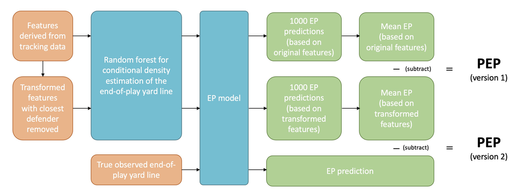

## Discussion

In this contribution, we developed a metric “PEP” for quantifying the value of a tackle. It allows practitioners to assess players, particularly in terms of their tackling abilities. However, there are a few drawbacks that need to be taken into account during the evaluation process. Important considerations are the position and the defensive playing styles of teams. Cornerbacks and safeties are often more capable of making “touchdown-saving tackles”, resulting in their values typically being higher. Furthermore, safeties who engage in riskier defensive strategies, such as those employed by Brian Flores, receive less support of their teammates in the backfield, which is why their metrics may be higher. When taking such aspects into account, however, the metric we have developed can serve as an additional puzzle piece in the overall assessment of (defensive) players and might gain practical relevance in the process of scouting players and opponents.

## Code

All code for data preprocessing, model training, prediction and player evaluation can be found [here](https://github.com/Rob2208/nfl_bdb_24).

## References

- Carl S, Baldwin B (2023). nflfastR: Functions to Efficiently Access NFL Play by Play Data. R package version 4.6.0.9000, https://github.com/nflverse/nflfastR, https://www.nflfastr.com/.
- Chen, T., & Guestrin, C. (2016). Xgboost: A scalable tree boosting system. In Proceedings of the 22nd acm sigkdd international conference on knowledge discovery and data mining (pp. 785-794).
- Yurko, R., Matano, F., Richardson, L. F., Granered, N., Pospisil, T., Pelechrinis, K., & Ventura, S. L. (2020). Going deep: models for continuous-time within-play valuation of game outcomes in American football with tracking data. Journal of Quantitative Analysis in Sports, 16(2), 163-182.